# Prioritisation_Workshop

Tin Buenafe and Sandra Neubert

2024-12-09

Hi there! Welcome to Conservation Planning in R by Sandra and Tin. This R Markdown will run through all the material (and more!) that we will cover in the workshop. While the code mostly reflects what’s already in the R Scripts (see the [Github repository](https://github.com/sandra-neubert/ConservationPlanning_Workshop) we set up), watch out for some coding tips and tricks that will be highlighted across this markdown.

*Notes: You can “show”/“hide” all code by clicking on the drop down box on the top right corner of the page. We have also added the option to copy the code in each code chunk.*

# Theory of conservation planning and spatial prioritization

Growing demands for food, energy, and infrastructure put marine ecosystems and their services at risk. To protect marine biodiversity against threats from the accelerating use of the marine environment, international targets aim to expand the global protected area network to 30% of the oceans by 2030. The Kunming-Montreal Global Biodiversity Framework of the Convention on Biological Diversity sets out the 2030 global agenda for nature conservation. Under this framework, 196 countries have committed to protect 30% of the planet through an ecologically-representative, well-connected, and equitably governed system of area-based conservation measures, as well as to restore 30% of degraded ecosystems (Targets 2 & 3) while adapting to climate change. Note that “biodiversity inclusive spatial planning” features prominently in the framework’s Target 1 “Ensure that all areas are under participatory, integrated, and biodiversity inclusive spatial planning and/or effective management processes…”.

In addition, United Nations member states recently adopted a treaty for the conservation and sustainable use of biodiversity in the High Seas, an ambitious goal considering <1% of the High Seas is currently highly protected. Meeting these international targets requires tools and methods that facilitate informed decision-making to balance biodiversity conservation with demands of industries using the environment.

Conservation planning helps stakeholders, the community and planners to work together to identify their resources and accomplish multiple objectives that are best for the land, water, and people (https://marxansolutions.org/whatisconservationplanning/). Conservation planning allows the prioritization of areas important for biodiversity conservation whilst minimizing economic costs, and to quantify ecological and economic impacts of decisions. Conservation planning tools are applicable to a wide range of conservation problems across marine, freshwater and terrestrial ecosystems. These problem can vary in spatial scale, type of biodiversity, managed uses, management actions, and budget. This workshop will teach you the core principles of conservation planning, thus providing the basic hands-on skills to formulate, solve, and interpret conservation problems and their solutions so you can apply conservation planning in your work.

*Spatial prioritization* refers to quantitative methods that aid in identifying priority areas for a particular action (e.g., conservation) while meeting certain criteria (e.g., meeting area-based targets). In a conservation context, spatial prioritization is used to identify areas for conservation. It is a step in a bigger, more elaborate process called *systematic conservation planning* that refers to the structured process of identifying, assigning, and monitoring areas for protection, conservation, or restoration. Read more about systematic conservation planning and spatial prioritization in [Margules and Pressey (2000)](https://www.nature.com/articles/35012251) and [Tallis et al. (2021)](https://nyaspubs.onlinelibrary.wiley.com/doi/10.1111/nyas.14651).

# Important terminology

Here are some key terms that you will need to know to run a prioritization.

**Planning region**: This is the spatial domain. It is subdivided into planning units.

**Planning units**: Spatial cells within the planning region, which are usually regular (grids or hexagons) or irregular shapes (e.g., bioregions).

**Planning problem**: This specifies all the information needed to define a spatial prioritization. This includes the planning region, the planning units, the features, costs, targets, and the objective function.

**Solution**: The output of the planning problem. Solutions are the protected areas selected. This is either binary (each planning unit is selected (1) or not selected (0) in the reserve system) or can be a proportion of each planning unit

**Feature**: The elements of interest (e.g., species, habitat, process, cultural site) that you want to protect in the reserve system by setting a target for each.

**Target**: The minimum quantity or proportion of each conservation feature in the planning region to be included in the solution (e.g., protect 30% of each habitat type in the reserve system).

**Cost**: Reflects the economic implications of including a planning unit in the reserve (along the coast it could be cost of land acquisition; in the ocean it could be the opportunity cost of lost fisheries revenue). Opportunity costs other than fishing can be included, such as for mining, oil/gas, aggregate extraction and shipping.

**Objective function**: Specifies the overall goal of a conservation planning problem. All conservation planning problems involve minimizing or maximizing an objective function. The standard objective function in Marxan (and one of the eight objectives in prioritizr) is the minimum set objective, which conserves enough of each feature to meet its target, while minimizing the overall cost of the reserve network.

# Introduction to spatial planning with *prioritizr*

We are going to demonstrate some of the fundamental skills needed in dealing with spatial data based on an example from the Galapagos Exclusive Economic Zone (EEZ). The data used in this workshop are not ours and we attribute the source of the data when we use them. Please also see the Reference section at the end of the notes. This data comes pre-prepared in the correct format.

## Installing required R packages

A really good R package to install the versions of the R packages that are in CRAN is **`pacman`**. We are going to install and load packages throughout the course of this workshop, but a common best practice is to install and load all necessary packages to run each script at the top of the R script.

To work through these notes you will need to install the add-on packages `tidyr`, `ggplot2` and `dplyr`. Or you can just get the package tidyverse which has these and more. We also need some packages for spatial data and spatial data wrangling (`sf`and `rnaturalearth`) and a few more for data visualisation (`patchwork` and `viridis`). And of course we need `prioritizr`, which we will use for conservation planning.

```r
install.packages("pacman")
pacman::p_load(tidyverse, sf, rnaturalearth, patchwork, prioritizr, viridis)
```

## Installing a solver

Solving conservation problems with `prioritizr` also requires having a solver installed on your machine. Solvers use specific algorithms that use mathematical optimization to find an optimal solution to a problem. There are many different solvers available that differ in terms of their efficiency and cost. The best solvers are usually expensive to use, but there are some good free ones available. For some more information on solver comparisons, see [this article](https://prioritizr.net/articles/solver_benchmarks.html) by Jeff Hanson, the developer of `prioritizr`.

For the purpose of this workshop, we recommend using one of the freely available solvers that are supported by `prioritizr` and are easily installed, such as the SYMPHONY solver, which can be installed using.

If you are a Windows user, lpsympony might work better. Check their website for more details: https://www.bioconductor.org/packages/release/bioc/html/lpsymphony.html

```r
if (!require(remotes)) install.packages("remotes")
remotes::install_bioc("lpsymphony")
```

If you are a Mac/Linux, rcbc might work better. Check their README for more details https://github.com/dirkschumacher/rcbc

```r
if (!require(remotes)) install.packages("remotes")
remotes::install_github("dirkschumacher/rcbc")
```

Alternatively, if the installation fails for some reason, on your machine, try installing the HiGHS solver.

```r
install.packages("highs")
```

If you are affiliated with an academic institution, you might have access to a free academic license of Gurobi, one of the state-of-the-art solvers out there. While we will not go through a step-by-step guide on how to install Gurobi here, there are many resources on how to install Gurobi, for example [this installation guide](https://prioritizr.net/articles/gurobi_installation_guide.html) on the `prioritizr` website. We recommend using this solver if you have access to it and want to use conservation planning for projects after this workshop.

## Study Site - The Galapagos

Today you are a conservation officer helping plan the Galapagos Marine Reserve. The Galapagos Islands and surrounding waters are recognized globally for their unique species and biodiversity, such as the endemic giant tortoises, Galapagos penguins and marine iguanas. In 1998, the Ecuadorian Government created a marine reserve, covering 138,000 km<sup>2</sup> around the islands, which at the time, made it the second largest marine reserve in the world. However, many of the species inhabiting Galapagos, such as the blue footed booby (*Sula nebouxii*) and silky shark (*Carcharhinus falciformis*), utilise the open ocean, and range outside the borders of the reserve. Thanks to tracking studies carried out over the quarter century since the creation of the reserve, we know much more about the movements of many of the species in and around the reserve, and can begin to address the question of whether the current reserve design provides adequate protection for them. We also know much more about the distribution of key ocean habitats in our region. Given that industrial and semi-industrial fishing pressure in Ecuador’s waters outside the reserve increased dramatically at the turn of the century, and that in recent years, large distant water fishing fleets have been reported in the high seas surrounding Ecuador’s Exclusive Economic Zone, the residents of Galapagos are concerned that the existing reserve may not provide sufficient protection to the ocean and wildlife that their livelihoods depend on. They are campaigning for an expansion of the reserve, and have asked us to identify key areas that should be included in their proposed new design. However, the fleets operating around the reserve are concerned that increasing the size of the reserve may affect their livelihoods. In addition to information on key habitats and species movements, we have obtained spatially explicit catch data from the two main fleets - the industrial tuna purse seine fleet and the national longline fleet for large pelagic species.

## Loading preliminaries

It is best practice to load and define all “preliminaries” at the start of your `R` script. These preliminaries range from R packages to variables used across the `R` script, but typically it encompasses anything and everything that is used and reused throughout the `R` script.

First, we load the necessary R packages. A really good R package to install the versions of the R packages that are in CRAN is **`pacman`**. We are going to install and load packages throughout the course of this workshop, but a common best practice is to install and load all necessary packages to run each script at the top of the R script.

*Notes: You can “show”/“hide” all code by clicking on the drop down box on the top right corner of the page. We have also added the option to copy the code in each code chunk.*

```r
install.packages("pacman")
```

Load the required packages and code. The code are custom utility functions that we have written to help automate certain tasks.

```r
pacman::p_load(tidyverse, sf, rnaturalearth, patchwork, prioritizr, viridis)
source("utils-functions.R")
```

Another best practice is to define the input paths as a variable to enhance the reproducibility of your `R` script. A good `R` package that breaches the difficulty of setting file paths in different Operating Systems (e.g., Windows syntax vs Mac), among other cool things, is the **`here`** `R` package. If you want to read more about the functionality of this package, take a look at [their website](https://here.r-lib.org/).

```r
inputDat <- file.path("Input") # Define file paths
```

Next, we define the Coordinated Reference System (CRS) that will be used throughout this `R` script. There are different ways to do this, but the two most common ones are using the *EPSG code* and the *PROJ4 strings*. Here’s a pdf that was prepared by M. Frazier and is freely available online that clearly explains the CRS syntax well. It is recommended to use the EPSG code or WKT (Well Known Text), but we find that using the PROJ4 string version of the CRS is useful for plotting maps that are not necessarily centered in the Meridian. But note PROJ4 is technically deprecated now so use with care.

Define CRS as the [Mollweide Projection](https://desktop.arcgis.com/en/arcmap/latest/map/projections/mollweide.htm)

```r
cCRS <- "ESRI:54009"
```

## Spatial data wrangling and spatial analysis

There are so many other things that we can do with spatial data in R aside from visualizing them. In this next section, we are going to wrangle spatial data, particularly the Marine Ecoregions of the World (MEOW) that is available online by using the `mregions` R package. The code chunk below shows the following things:

1. There are three different MEOWs within the Galapagos’.
2. We take the union of this three and make it into one polygon which will serve as our *planning region/study area* (using `st_union()`).
3. We then reproject this from an un-projected WGS84 vector to the Mollweide Equal-Area projection (using `st_transform()`).

```r
## Create a boundary
GalapEcoregions <- c(20172:20174)

meowDat <- mregions::mr_shp(key = "Ecoregions:ecoregions") %>%
  dplyr::filter(.data$eco_code %in% GalapEcoregions) %>% # dplyr::filter to make sure filter() function used is from the dplyr R package
  st_union() %>%
  st_as_sf() %>%
  st_transform(cCRS) %>%
  rename(geometry = x) %>%
  st_set_geometry(., "geometry")
```

[output not shown]

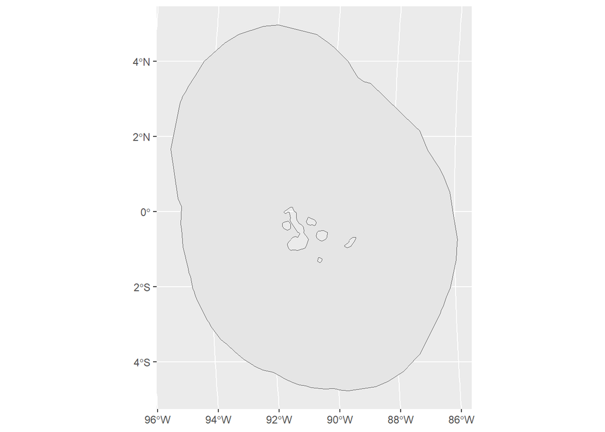

```r
ggplot() +
  geom_sf(data = meowDat)
```

We can also divide the entire planning region into discrete units using the `st_make_grid()` function. Here, we first show how to do this with square-shaped grids.

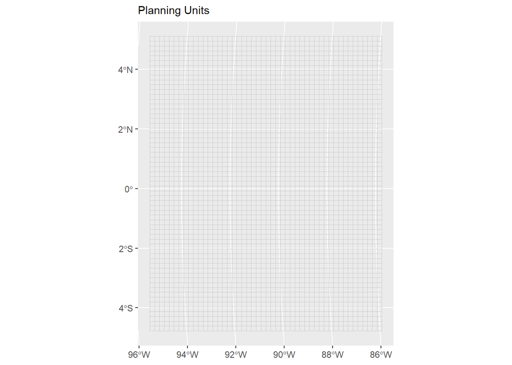

```r
## Make grid
### Use boundary to create grid
PUs <- st_make_grid(meowDat, cellsize = 20000) %>% #cellsize: opposite edges
  st_sf() %>%
  mutate(cellID = row_number()) # Add a cell ID reference

### Plot grid
gg_PUs <- ggplot() +
  geom_sf(data = PUs, colour = "grey80", fill = NA, size = 0.1, show.legend = FALSE)+
  coord_sf(xlim = st_bbox(PUs)$xlim, ylim = st_bbox(PUs)$ylim) +
  labs(subtitle = "Planning Units")

gg_PUs
```

Now we actually only want the planning units that fall within the EEZ and are more than half marine. For this we need information on where the land is.

```r
landmass <- rnaturalearth::ne_countries(
  scale = "medium",
  returnclass = "sf"
) %>%
  sf::st_transform(cCRS)
```

Now apply to planning units.

```r
# Then get all the PUs partially/wholly within the planning region
logi_Reg <- st_centroid(PUs) %>%
  st_intersects(meowDat) %>%
  lengths() > 0 # Get logical vector instead of sparse geometry binary
PUs <- PUs[logi_Reg, ] # Get TRUE

# Second, get all the pu's with < 50 % area on land (approximated from the centroid)
logi_Ocean <- st_centroid(PUs) %>%
  st_intersects(landmass) %>%
  lengths() > 0 # Get logical vector instead of sparse geometry binary
```

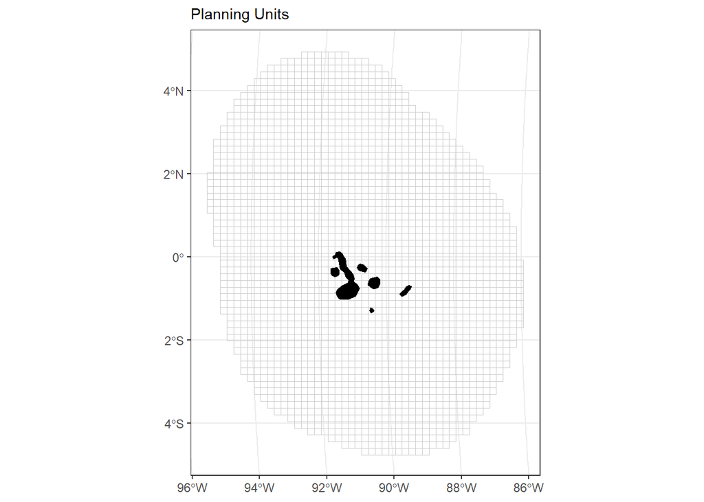

```r
dat_PUs <- PUs[!logi_Ocean, ] %>%
  mutate(cellID = row_number()) # Add a cell ID reference

### Plot grid
(gg_PUsLand <- ggplot() +
  geom_sf(data = dat_PUs, colour = "grey80", fill = NA, size = 0.1, show.legend = FALSE)+
  geom_sf(data = landmass, colour = "black", fill = "black", show.legend = FALSE) + #plot landmass
  coord_sf(xlim = st_bbox(meowDat)$xlim, ylim = st_bbox(meowDat)$ylim) + #crop landmass
  labs(subtitle = "Planning Units") +
  theme_bw())
```

Note: another tip to “evaluate”/“print” your code without having to call the variable in a separate line is enclosing the entire thing in parentheses ()!

## Loading the data

Before we can generate a spatial prioritization, we need to load the spatial data, which we have prepared.

```r
PUs <- st_read(file.path(inputDat, "PUs", "Galapagos_Planning_Units.shp")) %>%
  st_transform(cCRS) %>%
  select(-"cost") %>%
  rename(cellID = puid)
```

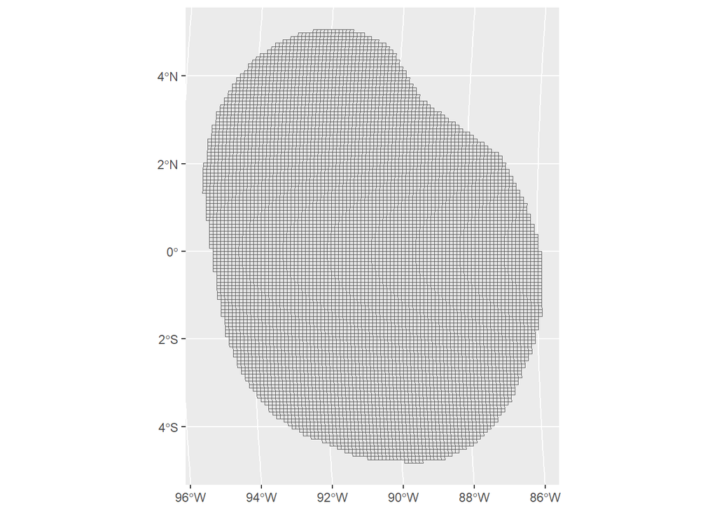

```r
ggplot() +
  geom_sf(data = PUs)
```

The `features` object describes the spatial distribution of the *features* (i.e., the species, habitats or whatever we care about that would have corresponding *targets*). The feature data are also saved as an `sf::st_sf()` object. In addition to the `cellID` and `geometry` columns, each column corresponds to a feature we are interested in protecting. Values of the features denote the presence (using value of 1) or absence (using value of 0) across the study area.

```r
features <- readRDS(file.path(inputDat, "Features", "Features_Combined.rds"))
```

Lets have a look at some of the features using `ggplot()`.

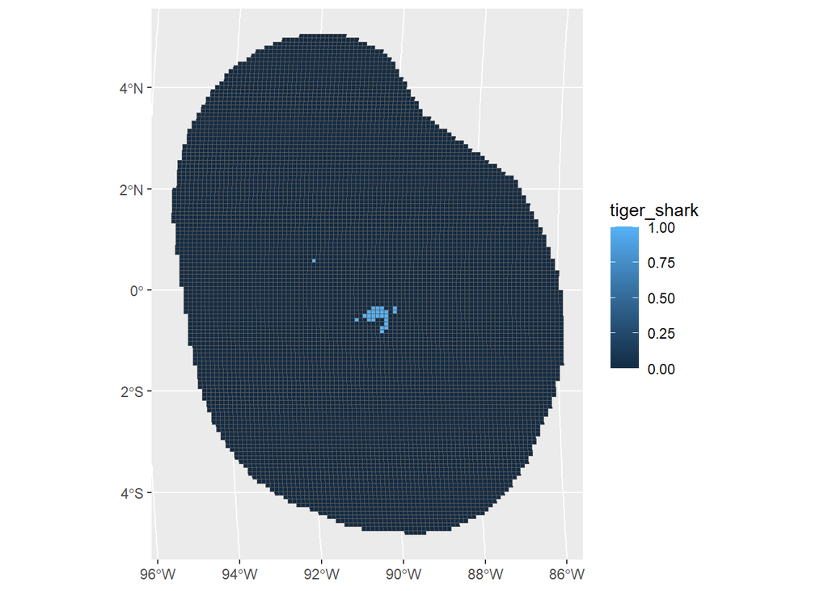

```r
ggplot() +
  geom_sf(data = features, aes(fill = tiger_shark))
```

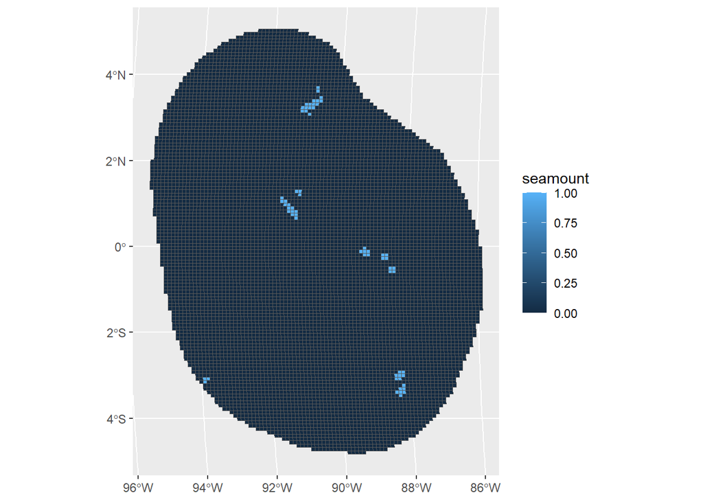

```r
ggplot() +
  geom_sf(data = features, aes(fill = seamount))
```

## Load Cost

As conservation and management actions are often restricted by costs, we therefore seek to meet targets, while minimizing costs and other impacts on industries, communities or other stakeholders. For this scenario, we will use the cost to the fishing industry. This is a layer that reflects the economic value derived within a given cell for the two primary fishing fleets operating in the Galapagos: the artisanal long-line pelagic fleet, and the industrial tuna purse-seine fleet.

Because there is no fishing allowed in the marine reserve, the cost is negligible and so prioritizr will preference meeting targets in these low-cost areas.

```r
cost <- st_read(file.path(inputDat, "Cost", "cost_surface.shp")) %>%
  st_transform(cCRS) %>%
  rename(cellID = puid)
```

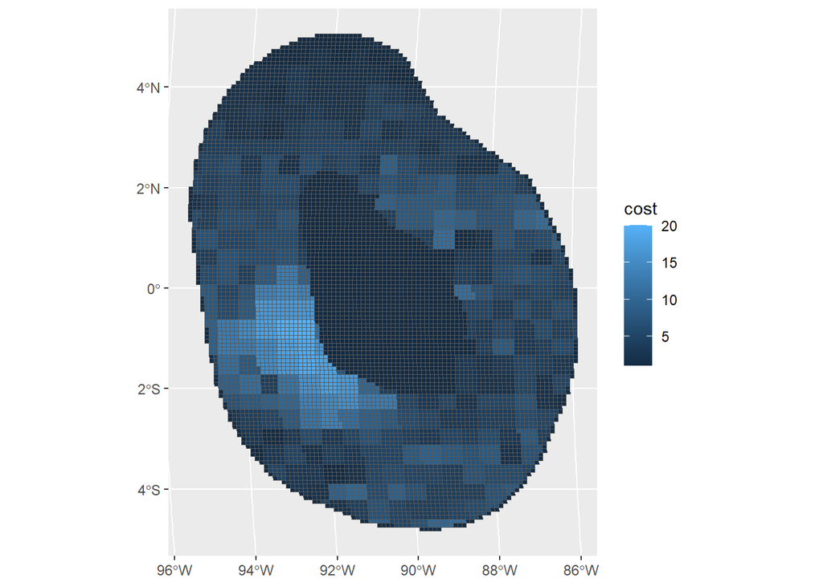

```r
ggplot() +
  geom_sf(data = cost, aes(fill = .data$cost))
```

Add cost to combined sf object.

```r
out_sf <- features %>%
  left_join(cost %>% sf::st_drop_geometry(), by = "cellID")
```

## Setup prioritization

Now, we do the actual spatial prioritization. We are going to use the **`R` package `prioritizr`** to run the prioritizations. Apart from loading the spatial data, we need to prepare a couple of things for `prioritizr`. We first need to know the “names” (or their identifiers in the dataset) of the *features.*

```r
# Extract feature names
col_name <- features %>%
  select(-"cellID") %>%
  st_drop_geometry() %>%
  colnames()
```

We then need the *targets* that we are assigning for each feature. Here, we show how we can assign equal targets for all features and how we can also assign different targets for different features. In a practical conservation planning setting, you would set higher targets to features that are more important.

```r
# Same target for all
targets <- rep(0.3, length(col_name))


# Assign higher target for species with tracking data
targets <- data.frame(feature = col_name) %>%
  mutate(Category = c(rep("Geomorphic", 12), rep("Tracking Data", 5))) %>%
  mutate(target = if_else(Category == "Tracking Data", 50 / 100, 5 / 100))
```

## Run prioritsation

We now have all the necessary information needed to run the prioritization. Next, we set up the conservation “problem” using `problem()` from `prioritizr`. In this function, we define all the spatial data (i.e., in this example, the object `out_sf`), what the features are called in `out_sf`, and the what the cost’s column name is in `out_sf`. We then use the minimum set objective function to solve this conservation problem (i.e., minimizing the cost while meeting all of the features’ targets) using `add_min_set_objective()`. We also assign the targets for each of the features using `add_relative_targets()`. The result of solving this conservation problem would be a binary one (1/0, yes/no, TRUE/FALSE), so the algorithm will assign whether a planning unit has been selected or not selected (using `add_binary_decisions()`).

```r
dat_problem <- problem(out_sf,
                       features = col_name,
                       cost_column = "cost"
) %>%
  add_min_set_objective() %>%
  add_relative_targets(targets$target) %>%
  add_binary_decisions() %>%
  add_default_solver(verbose = FALSE)
```

Then, we solve the prioritization using `solve.ConservationProblem()`.

```r
dat_soln <- dat_problem %>%
  solve.ConservationProblem()

# saveRDS(dat_soln, file.path("Output", "Solution1.rds"))
```

And there you have it, you have generated a spatial prioritization! “Solving” the conservation “problem” is a bit anticlimactic, but this shows that most of the work to generate a spatial prioritization is to preprocess and wrangle the spatial data.

Let us plot the solution and see what it looks like.

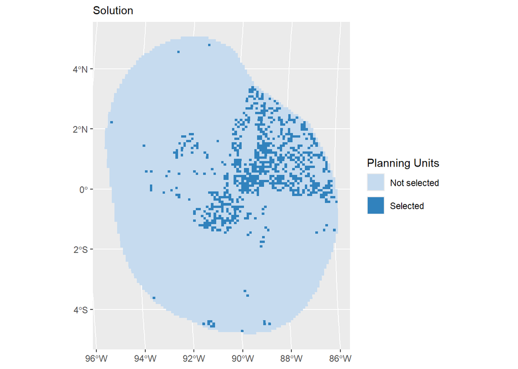

```r
# Plot solution with a function we have defined (i.e., it is not in prioritizr)
# This makes a prettier plot than using the default plot function in prioritizr
(gg_sol <- splnr_plot_Solution(dat_soln))
```

```r
targ_coverage <- eval_target_coverage_summary(dat_problem, dat_soln[, "solution_1"])
```

## Adding Penalties

Penalties can be added to the conservation problem as a way to penalize solutions according to a certain metric. Penalizing certain criteria (e.g. certain environmental conditions, activities etc.) leads to a trade-off in the objective function, which aims to minimise the cost. Increasing the “cost” of a planning units through a penalty causes planning units that are not penalized to be selected over those that are.

### Penalty 1: Boundary penalty

The **boundary penalty** helps the user decide how “clumped” the network should be. Often, it is not feasible to enforce a network of fragmented protected areas (as often happens when we optimize with no design constraints). For this reason, we need to adjust the **boundary penalty** to ensure we can minimize fragmentation and aggregate planning units into patches or clumps. There is no perfect value for the **boundary penalty** so we encourage users to explore different levels to see the effect.

Set up conservation problem.

```r
# Add penalties
datEx_problem_P <- problem(out_sf,
                           features = col_name,
                           cost_column = "cost"
) %>%
  add_min_set_objective() %>%
  add_relative_targets(targets$target) %>%
  add_boundary_penalties(0.2) %>%
  add_binary_decisions() %>%
  add_default_solver(gap = 0.5, verbose = FALSE) # Larger optimality gap to speed up code
```

Solve conservation problem.

```r
datEx_soln_P <- datEx_problem_P %>%
  solve.ConservationProblem()
```

[output not shown]

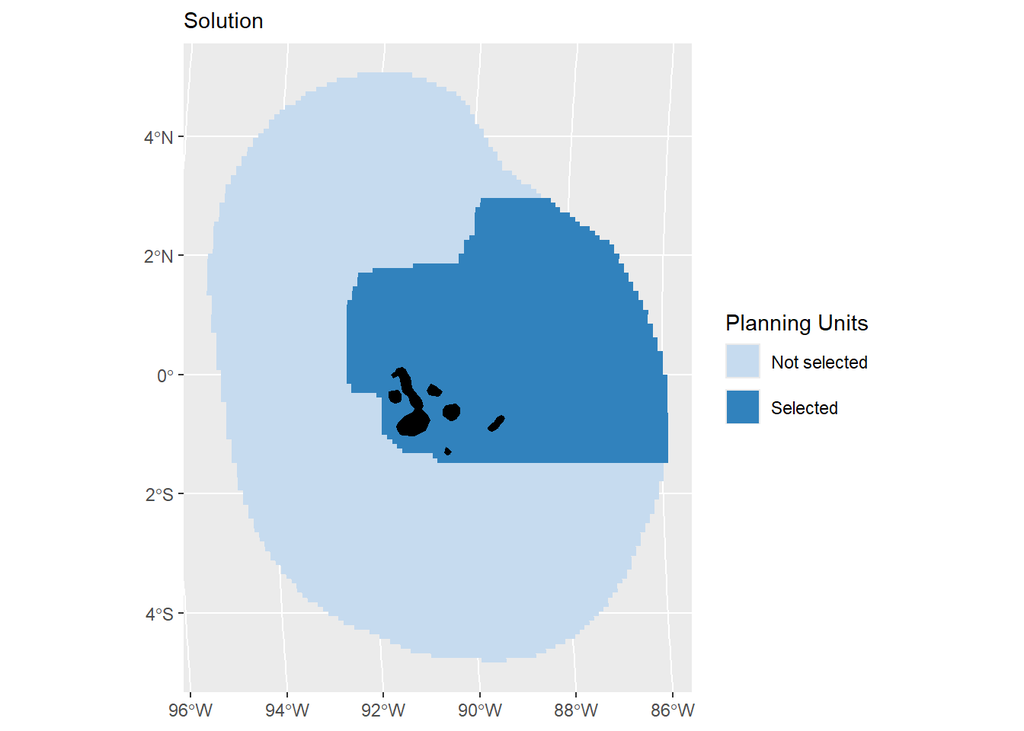

```r
(gg_solnP <- splnr_plot_Solution(datEx_soln_P) +
   geom_sf(data = landmass,
           colour = "black", fill = "black", show.legend = FALSE) +
   coord_sf(xlim = st_bbox(PUs)$xlim, ylim = st_bbox(PUs)$ylim))
```

The selected PUs are more aggregated BUT, in an example with varying cost this might also lead to a more expensive solution

There are several types of penalties, so it is worthwhile browsing through the `prioritizr` [Reference tab](https://prioritizr.net/reference/index.html#penalties) for more information.

## Adding Constraints

The conservation problems so far were relatively simple. In reality, it is often required to add more complexity. A constraint can be added to a conservation planning problem to ensure that solutions exhibit a specific characteristic.

### Constraint 1: Locked-in areas

One example for constraints is locking in specific areas, for example already existing MPAs. These MPA will have to be part of the final solution - after all, they are **locked-in**.

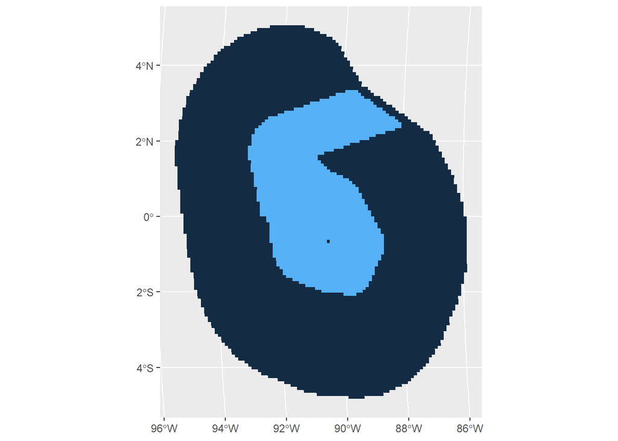

```r
mpas <- readRDS(file.path(inputDat, "MPAs", "mpas.rds"))

# First look at the data
(gg_mpas <- ggplot() +
    geom_sf(data = mpas, aes(fill = .data$mpas),
            colour = NA, size = 0.001, show.legend = FALSE))
```

The conservation problem.

[output not shown]

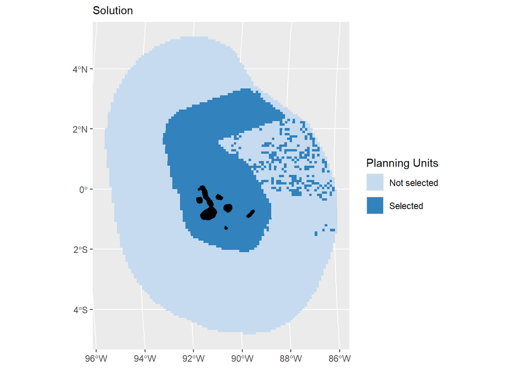

```r
datEx_problem_LIC <- problem(out_sf,
                             features = col_name,
                             cost_column = "cost"
) %>%
  add_min_set_objective() %>%
  add_relative_targets(targets$target) %>%
  add_locked_in_constraints(as.logical(mpas$mpas)) %>%
  add_binary_decisions() %>%
  add_default_solver(verbose = FALSE)

# Solve conservation problem
datEx_soln_LIC <- datEx_problem_LIC %>%
  solve.ConservationProblem()

(gg_solnLIC <- splnr_plot_Solution(datEx_soln_LIC) +
    geom_sf(data = landmass,
            colour = "black", fill = "black", show.legend = FALSE) +
    coord_sf(xlim = st_bbox(PUs)$xlim, ylim = st_bbox(PUs)$ylim))
```

## Adding Zones

Many real-world conservation problems do not simply involve deciding if an area should be protected or not. In reality, many problems involve a range of different types of management and the goal is to determine which areas should be allocated to which type of management. We can construct such a conservation problem to have different management zones, using the function `zones()`.

```r
# Create Targets
targetsZones <- data.frame(feature = col_name) %>%
  mutate(Category = c(rep("Geomorphic", 12), rep("Tracking Data", 5))) %>%
  mutate(
    targetZ1 = dplyr::if_else(Category == "Tracking Data", 30 / 100, 0),
    targetZ2 = dplyr::if_else(Category != "Tracking Data", 10 / 100, 0)
  ) %>%
  dplyr::select("targetZ1", "targetZ2") %>%
  as.matrix()

# Create zones object
z1 <- zones("zone 1" = col_name, "zone 2" = col_name)

# Set up conservation problem
# NOTE: when using sf input, we need as many cost columns as we have zones
datEx_problem_zones <- prioritizr::problem(
  out_sf %>%
    mutate(
      Cost1 = rep(1, nrow(.)),
      Cost2 = rep(1, nrow(.))
    ),
  z1,
  cost_column = c("Cost1", "Cost2")
) %>%
  add_min_set_objective() %>%
  add_relative_targets(targetsZones) %>%
  add_binary_decisions() %>%
  add_default_solver(verbose = FALSE)

# Solve conservation problem
datEx_soln_zones <- datEx_problem_zones %>%
  solve.ConservationProblem()
```

We can examine the solution.

[output not shown]

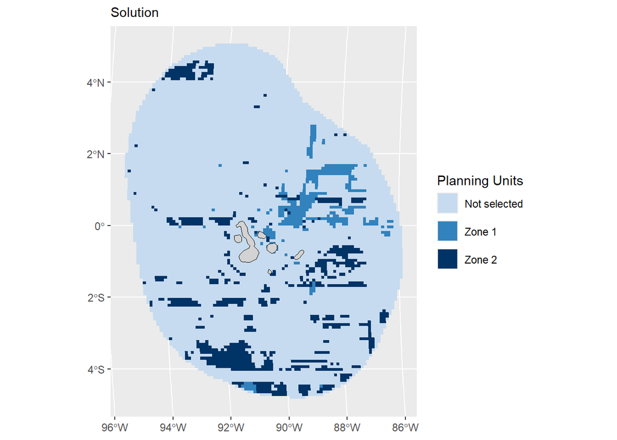

```r
(gg_soln_zones <- splnr_plot_Solution(
  datEx_soln_zones,
  zones = TRUE,
  colorVals = c("#c6dbef", "#3182bd", "#003366"),
  legendLabels = c("Not selected", "Zone 1", "Zone 2")
) +
  geom_sf(data = landmass,
          colour = "black", fill = "lightgrey", show.legend = FALSE) +
  coord_sf(xlim = st_bbox(PUs)$xlim, ylim = st_bbox(PUs)$ylim))
```

```r
# Feature representation
targetsMet_zones <- datEx_soln_zones %>%
  select(tidyselect::starts_with(c("solution"))) %>%
  st_drop_geometry() %>%
  as_tibble() %>%
  eval_feature_representation_summary(datEx_problem_zones, .)
```

# Closing remarks

And that’s the workshop folks!

We hope you’ve learned something new along the way, whether it’s a coding tip/trick, a new concept or a new skill! We also hoped you had fun!! With this workshop, we wanted to show how different skills, such as handling spatial data, can be used in conservation exercises. If you have any questions, please feel free to contact Sandra (s.neubert@uq.edu.au) or Tin (k.buenafe@uq.edu.au).

# References

Acuña-Marrero, D., Smith, A.N.H., Hammerschlag, N., Hearn, A., Anderson, M.J., Calich, H., Pawley, M.D.M., Fischer, C., Salinas-de-León, P., 2017. Residency and movement patterns of an apex predatory shark (Galeocerdo cuvier) at the Galápagos Marine Reserve. PLoS One 12, e0183669.

Galapagos Movement Consortium, Movebank Data Repository https://www.movebank.org/cms/movebank-main Harris, P.T., Macmillan-Lawler, M., Rupp, J. and Baker, E.K., 2014. Geomorphology of the oceans. Marine Geology, 352, pp.4-24.

Hearn, A.R., Acuña, D., Ketchum, J.T., Peñaherrera, C., Green, J., Marshall, A., Guerrero, M., Shillinger, G., 2014. Elasmobranchs of the Galápagos Marine Reserve, In (J. Denkinger, L. Vinueza, eds.) Galápagos Marine Reserve: a dynamic socio-ecological system., pp. 23-59. Springer.

Hearn, A.R., Green, J., Román, M.H., Acuña-Marrero, D., Espinoza, E., Klimley, A.P., 2016. Adult female whale sharks make long-distance movements past Darwin Island (Galápagos, Ecuador) in the Eastern Tropical Pacific. Marine Biology 163, 214.

Hearn, A.R., Espinoza, E., Ketchum, J., Green, J., Peñaherrera, C., Arauz, R., Fischer, C., Steiner, T., Shillinger, G., Henderson, S., Bessudo, S., Soler, G., Klimley, P., 2017. Una década de seguimiento de los movimientos de tiburones resalta la importancia ecológica de las islas del norte: Darwin y Wolf, In (L. Cayot, D. Cruz, eds.) Informe Galápagos 2015-2016. pp. 132-142. DPNG, CGREG, FCD & GC, Puerto Ayora, Galápagos, Ecuador.

Hearn A, Cárdenas S, Allen H, Zurita L, Gabela-Flores MV, Peñaherrera-Palma CR, Castrejón M, Cruz S, Kelley D, Jeglinski J, Bruno J, Jones J, Naveira-Garabato A, Forryan A, Viteri C, Picho J, Donnelly A, Tudhope A, Wilson M & G Reck G (2022). A Blueprint for Marine Spatial Planning of Ecuador’s Exclusive Economic Zone around the Galápagos Marine Reserve. Universidad San Francisco de Quito / PEW Bertarelli Ocean Legacy, Quito, Ecuador, 361 p.

Parra, D.M., Andrés, M., Jiménez, J., Banks, S., Muñoz, J.P., 2013. Evaluación de la incidencia de impacto de embarcaciones y distribución de la tortuga verde (Chelonia mydas) en Galápagos. Retrieved from Puerto Ayora, Galapagos, Ecuador

Seminoff, J.A., Zárate, P., Coyne, M., Foley, D.G., Parker, D., Lyon, B.N., Dutton, P.H., 2008. Post-nesting migrations of Galápagos green turtles Chelonia mydas in relation to oceanographic conditions: integrating satellite telemetry with remotely sensed ocean data. Endangered Species Research 4, 57-72

Shillinger, G.L., Swithenbank, A.M., Bailey, H., Bograd, S.J., Castelton, M.R., Wallace, B.P., Spotila, J.R., Paladino, F.V., Piedra, R., Block, B.A., 2011. Vertical and horizontal habitat preferences of post-nesting leatherback turtles in the South Pacific Ocean. Marine Ecology Progress Series 422, 275-289.